# Poisson Regression - Crabs Data Set

# The crabs data set

The crabs data set is derived from Agresti (2007, Table 3.2, pp.76-77). It gives 4 variables for each of 173 female horseshoe crabs.

- *Satellites* number of male partners in addition to the female’s primary partner
- *Width* width of the female in centimeters
- *Dark* a binary factor indicating whether the female has dark coloring (yes or no)
- *GoodSpine* a binary factor indicating whether the female has good spine condition (yes or no)

```r
library(glm2)

data(crabs)
head(crabs) %>% kable()
```

| Satellites | Width | Dark | GoodSpine | Rep1 | Rep2 |
| --- | --- | --- | --- | --- | --- |
| 8 | 28.3 | no | no | 2 | 2 |
| 0 | 22.5 | yes | no | 4 | 5 |
| 9 | 26.0 | no | yes | 5 | 6 |
| 0 | 24.8 | yes | no | 6 | 6 |
| 4 | 26.0 | yes | no | 6 | 8 |
| 0 | 23.8 | no | no | 8 | 8 |

```r
summary(crabs[,1:4])  %>% kable()
```

|  | Satellites | Width | Dark | GoodSpine |
| --- | --- | --- | --- | --- |
|  | Min. : 0.000 | Min. :21.0 | no :107 | no :121 |
|  | 1st Qu.: 0.000 | 1st Qu.:24.9 | yes: 66 | yes: 52 |
|  | Median : 2.000 | Median :26.1 | NA | NA |
|  | Mean : 2.919 | Mean :26.3 | NA | NA |
|  | 3rd Qu.: 5.000 | 3rd Qu.:27.7 | NA | NA |
|  | Max. :15.000 | Max. :33.5 | NA | NA |

#### Question

Fit a Poisson regression model with the number of Satellites as the outcome and the width of the female as the covariate.

```r
crabs.pois <- glm2( Satellites ~ Width, data=crabs, family="poisson")

summary(crabs.pois)
```

```
##
## Call:
## glm2(formula = Satellites ~ Width, family = "poisson", data = crabs)
##
## Deviance Residuals:
##     Min       1Q   Median       3Q      Max
## -2.8526  -1.9884  -0.4933   1.0970   4.9221
##
## Coefficients:
##             Estimate Std. Error z value Pr(>|z|)
## (Intercept) -3.30476    0.54224  -6.095  1.1e-09 ***
## Width        0.16405    0.01997   8.216  < 2e-16 ***
## ---
## Signif. codes:  0 '***' 0.001 '**' 0.01 '*' 0.05 '.' 0.1 ' ' 1
##
## (Dispersion parameter for poisson family taken to be 1)
##
##     Null deviance: 632.79  on 172  degrees of freedom
## Residual deviance: 567.88  on 171  degrees of freedom
## AIC: 927.18
##
## Number of Fisher Scoring iterations: 6
```

```r
exp(-3.30476)*exp(0.164*25)
```

```
## [1] 2.214973
```

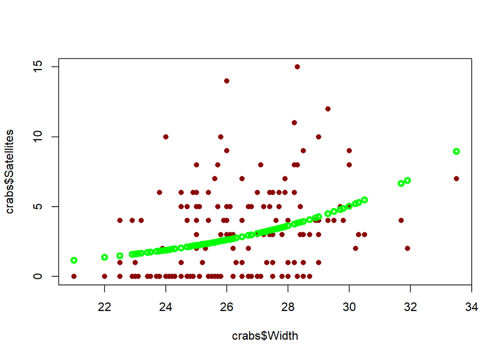

```r
plot(crabs$Width, crabs$Satellites,
     pch=16, col="darkred")
points(crabs$Width, crabs.pois$fitted.values,
     col="green", type="p", lwd=3)
```

### Question

What is the expected number of Satellites for a female of width 22cm?

Given a set of parameters $\{\beta_0,\beta_1, \ldots, \beta_n\}$ and an input vector $x$ (i.e $\{x_1,x_2, \ldots x_n\}$), the mean of the predicted Poisson distribution is given by
$$\operatorname{E}(Y|x)=e^{\beta_0+\beta_1x_1 + \ldots + \beta_nx_n}\,$$
In the case of one predictor variable, we can say
$$\operatorname{E}(Y|x)=e^{\beta_0+\beta_1x}=e^{\beta_0}\times e^{\beta_1x}\,$$

*Remark*: The expected value does not have to be an integer.

```r
exp(-3.30476)*exp(0.16405*22)
```

```
## [1] 1.35573
```